# DTCC Analysis

Davide Magno

### Reconciliation of the SwapPricer vs Bloomberg

First step is to make sure that the SwapPricer package is able to price the contracts we want to focus on (ie. USD fixed-float swaps).

I have loaded in the *Data* folder a set of documents I was able to download from Bloomberg.

Let’s setup the run:

1. First of all download SwapPricer from Github

```r
# Remove the comment once installed
# remotes::install_github("DavideMagno/SwapPricer")
```

2. We define a custom swap portfolio. The notional is equal to the average notional traded on the DTCC report and 10 years of duration. We test both at par and not at par swaps.

```r
portfolio <- tibble::tribble(
  ~ID, ~currency, ~notional, ~start.date, ~maturity.date, ~strike, ~type, ~standard,
  "ATM", "USD", 80000000, "18-06-2021", "18-06-2031", 0.01396766, "receiver", TRUE,
  "OTM", "USD", 80000000, "18-06-2021", "18-06-2031", 0.01000000, "receiver", TRUE
)
```

3. We load the swap curve as in the file “Curve.xlsx” in the SwapPricing folder

```r
curve <- readxl::read_excel(here::here("Data/SwapPricing/Curve.xlsx")) |>
  dplyr::select(Date = `Maturity Date`, df = Discount) |>
  dplyr::mutate(Date = as.Date(Date, "%m/%d/%Y")) |>
  tibble::add_row(Date = as.Date("2021-06-18"), df = 1, .before = 1)
```

Some R technical notes:

- I use the latest version of R (4.1.0) which has recently introduced a native pipe operator (you can read more about it [here](https://towardsdatascience.com/the-new-native-pipe-operator-in-r-cbc5fa8a37bd)). Let me know if you can’t manage to update it (*OK I’ve updated my desktop version to R-4.1.0 and updated RStudio too*)
- I always use the notation *package::function* because a) typically it is the most common way of coding for packages and b) it removes any ambiguity on whether a function is native R or belongs to a package. A bit more verbose but it goes well with the piping
- I use the **here** package because it allows not to reset any directory when two (or more) people work on the same file on two (or more) different computers
4. We setup the curve as required by the SwapPricer package

```r
usd.curve <- list()
usd.curve$currency <- "USD"
usd.curve$discount <- curve
```

5. Before we can price the swaps, we need to load the time series of the libor for the floating rate: FRED has in fact stopped contributing it on the api, hence I downloaded a csv file from their [website](https://fred.stlouisfed.org/series/USD3MTD156N)

```r
LiborRate <- readr::read_csv(here::here("Data/LiborRate.csv"))
```

6. We can now price the two swaps:

```r
pricing.day <- as.Date("2021-06-18")
SwapPricer::SwapPortfolioPricing(portfolio, pricing.day, usd.curve, LiborRate)
```

| swap.id | currency | notional | clean.mv | dirty.mv | accrual.pay | accrual.receive | par | pv01 |
| --- | --- | --- | --- | --- | --- | --- | --- | --- |
| ATM | USD | 8e+07 | 26954.08 | 26954.08 | 0 | 0 | 0.01393201 | -75598.44 |
| OTM | USD | 8e+07 | -2972535.10 | -2972535.10 | 0 | 0 | 0.01393201 | -75598.44 |

We compare the pricing with the screenshots from Bloomberg, starting from the ATM one:

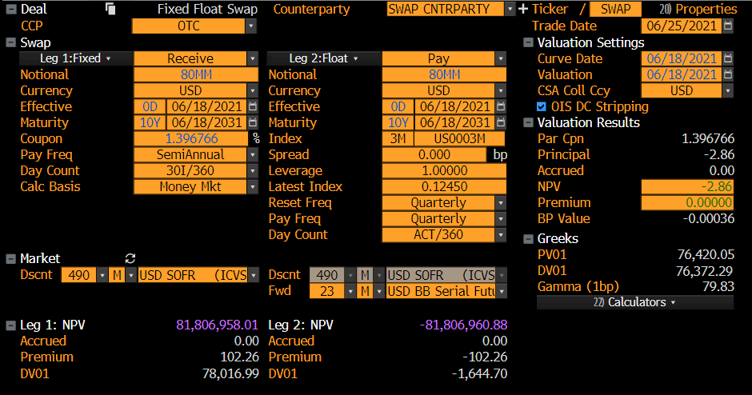

The difference in pricing is pretty close: $27k of difference in MTM which is almost 0.35 times the pv01. Difference in pv01 is $900

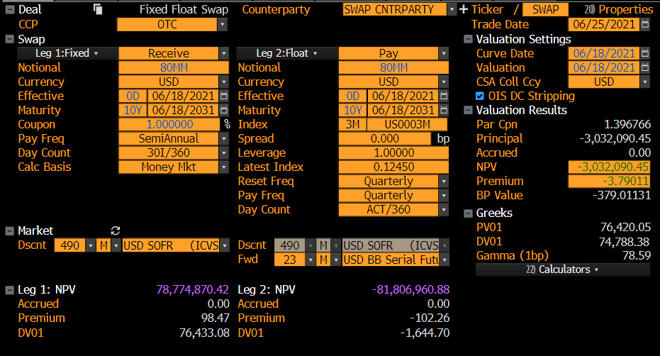

Difference in pricing has increased to $60k, which is still less than 1 pv01 (0.79)

**Pricing is therefore in line with Bloomberg and we can use it for estimates**

### Data wrangling the DTCC Report

Let’s start the analysis by loading the file

```r
date <- "2021_06_18"

# I use the readr package to read csvs because it doesn't assume that strings are factors by default

IRTrade <- readr::read_csv(here::here(paste0("Data/DTCC",date,".csv")))
```

As agreed, let’s start focusing only on:

- newly traded
- ATM
- Fixed-Float interest rate swaps
- cleared
- in USD
- standard conventions (this can be relaxed in the future)

```r
swaps <- IRTrade |>
  dplyr::mutate(`Notional Amount 1` = stringr::str_remove_all(`Notional Amount 1`, "\\,") |>
                    stringr::str_remove("\\+") |>
                    as.numeric()) |>
  dplyr::filter(`Product ID` == "InterestRate:IRSwap:FixedFloat",
                Action == "NEW",
                `Transaction Type` == "Trade",
                `Notional Currency 1` == "USD",
                `Payment Frequency Period 1` %in% c("3M", "6M"),
                `Payment Frequency Period 2` %in% c("3M", "6M"),
                Cleared == "C",
                `Block Trade Election Indicator` == "N",
                is.na(`Other Payment Amount`),
                grepl("N",`Non-Standardized Pricing Indicator`))
```

We now have to put the swaps information in the right format for the SwapPricer:

```r
swap.DTCC.portfolio <- swaps |>
  dplyr::summarise(ID = `Dissemination ID`,
                   currency = `Notional Currency 1`,
                   notional = `Notional Amount 1` |>
                     stringr::str_replace_all(",","") |>
                     as.numeric(),
                   start.date = as.character(`Effective Date`, format = "%d/%m/%Y"),
                   maturity.date = as.character(`Expiration Date`, format = "%d/%m/%Y"),
                   strike = dplyr::if_else(
                     is.na(`Fixed Rate 1`),`Fixed Rate 2`, `Fixed Rate 1`),
                   type = dplyr::if_else(
                     is.na(`Fixed Rate 1`), "payer", "receiver"),
                   standard = TRUE)
```

and price them using the swap pricer.

```r
priced.DTCC.portfolio <- SwapPricer::SwapPortfolioPricing(swap.DTCC.portfolio, pricing.day, usd.curve, LiborRate)

priced.DTCC.portfolio
```

| swap.id | currency | notional | clean.mv | dirty.mv | accrual.pay | accrual.receive | par | pv01 |
| --- | --- | --- | --- | --- | --- | --- | --- | --- |
| 204757014 | USD | 2.5e+07 | -6.798048e+04 | -6.798048e+04 | 0.000000e+00 | 0.000000e+00 | 0.011743856 | 16946.6414 |
| 204757015 | USD | 7.0e+06 | -1.466392e+05 | -1.466392e+05 | 0.000000e+00 | 0.000000e+00 | 0.017017864 | 16623.1886 |
| 204775978 | USD | 1.7e+07 | -4.426014e+04 | -4.426014e+04 | 0.000000e+00 | 0.000000e+00 | 0.013954514 | 16066.1839 |
| 204776000 | USD | 7.9e+07 | 1.907474e+05 | 1.907474e+05 | 0.000000e+00 | 0.000000e+00 | 0.013954514 | -74660.5018 |
| 204776001 | USD | 1.5e+08 | -1.772385e+05 | -1.772385e+05 | 0.000000e+00 | 0.000000e+00 | 0.009244447 | 73679.7546 |
| 204776031 | USD | 5.0e+06 | 2.952852e+04 | 2.952852e+04 | 0.000000e+00 | 0.000000e+00 | 0.016424491 | -14646.4544 |
| 204776034 | USD | 2.2e+07 | -1.977632e+04 | -1.977632e+04 | 0.000000e+00 | 0.000000e+00 | 0.019051943 | 9985.1681 |
| 204776043 | USD | 2.0e+08 | -1.929898e+05 | -1.929898e+05 | 0.000000e+00 | 0.000000e+00 | 0.007574843 | 79124.4887 |
| 204776044 | USD | 1.3e+08 | -2.071956e+04 | -2.071956e+04 | 0.000000e+00 | 0.000000e+00 | 0.005577866 | 38812.4205 |
| 204776045 | USD | 8.0e+07 | -1.053336e+05 | -1.053336e+05 | 0.000000e+00 | 0.000000e+00 | 0.009244447 | 39295.8691 |

[output cut: 1768 more lines]

The pricing allows us to infer some interesting information on the swaps traded on the day:

1. Not all the swaps could be priced. A significant number in fact has **NA** as market value. Let’s analyse them from a time to maturity perspective:

```r
not.priced.ids <- priced.DTCC.portfolio |>
  dplyr::filter(is.na(clean.mv)) |>
  dplyr::pull(swap.id)

swap.DTCC.portfolio |>
  dplyr::filter(ID %in% not.priced.ids) |>
  dplyr::mutate(time.to.mat = (lubridate::dmy(maturity.date) - lubridate::dmy(start.date))) |>
  dplyr::select(ID, start.date, maturity.date, time.to.mat) |>
  dplyr::count(time.to.mat)
```

| time.to.mat | n |
| --- | --- |
| 89 days | 4 |
| 90 days | 4 |
| 91 days | 33 |
| 92 days | 56 |
| 98 days | 13 |

We can see that the swaps not priced have a time to maturity of around 3 months. We can then remove them from the analysis as they are actually FRAs rather than swaps.

```r
`%notin%` <- Negate(`%in%`)

priced.DTCC.portfolio <- priced.DTCC.portfolio |>
  dplyr::filter(swap.id %notin% not.priced.ids)

swap.DTCC.portfolio <- swap.DTCC.portfolio |>
  dplyr::filter(ID %notin% not.priced.ids)
```

2. Even though most of the swaps are supposed to be priced at par, we can notice that the market value is significantly different from 0. The deviation column calculates the difference from a 0 market value in numbers of pv01s.

```r
priced.DTCC.portfolio |>
  dplyr::summarise_if(is.numeric, sum) |>
  dplyr::select(-par) |>
  dplyr::mutate(deviation = clean.mv/pv01)
```

| notional | clean.mv | dirty.mv | accrual.pay | accrual.receive | pv01 | deviation |
| --- | --- | --- | --- | --- | --- | --- |
| 102851590000 | -143684879 | -143949371 | -341079.3 | 76587.36 | 30402795 | -4.726042 |

We can therefore analyse the fixed rates in the DTCC file (black dots), vs the swap curve from BBG that we used for pricing (red dots - we only included actual swap rates, without extrapolating them from the middle part of the curve made of swaptions)

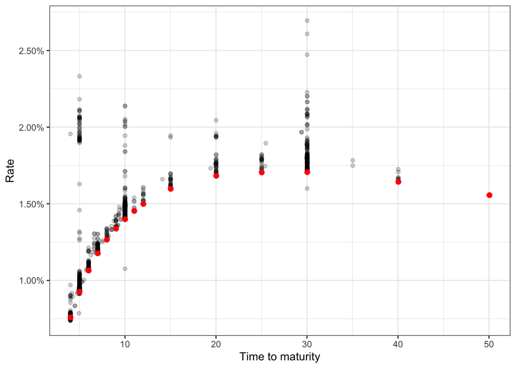

We can notice that: - there is a significantly wide range of strikes traded especially on the 5, 10 and 30 years maturity. Are these out of the money trades or do intra-day movements justify these deviations? Let’s analyse the dynamic of the intraday rate from Bloomberg:

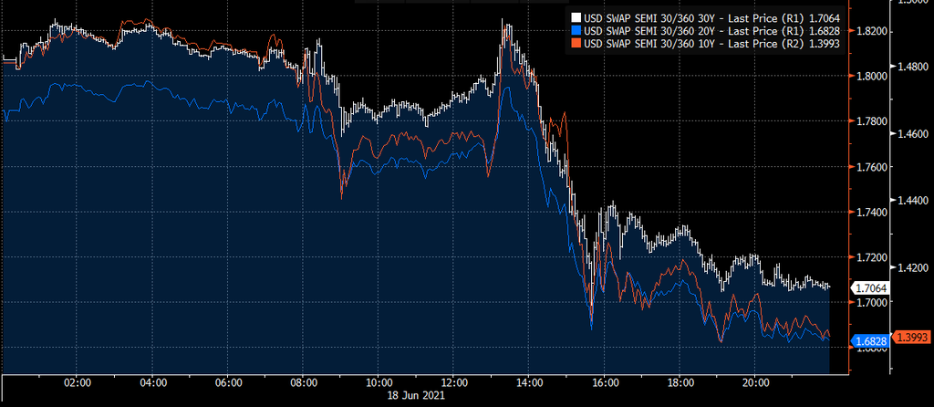

From the analysis, the number of trades that have been struck outside the range of reasonable levels of moneyness is 169 out of 1668.

Let’s analyse the pricing to see where most of the differences come from:

```r
non.atm.ids <- strike.table |>
  dplyr::select(ID) |>
  dplyr::mutate(ID = as.character(ID),
                group = "Not ATM")

priced.DTCC.portfolio |>
  dplyr::left_join(non.atm.ids, by = c("swap.id" = "ID")) |>
  dplyr::mutate(group = dplyr::if_else(is.na(group), "ATM", "Not ATM")) |>
  dplyr::group_by(group) |>
  dplyr::summarise_if(is.numeric, sum) |>
  dplyr::select(-par) |>
  dplyr::mutate(deviation = clean.mv/pv01)
```

| group | notional | clean.mv | dirty.mv | accrual.pay | accrual.receive | pv01 | deviation |
| --- | --- | --- | --- | --- | --- | --- | --- |
| ATM | 96185590000 | -100687112 | -100695474 | -9956.604 | 1594.749 | 28934306 | -3.479852 |
| Not ATM | 6666000000 | -42997768 | -43253898 | -331122.662 | 74992.608 | 1468489 | -29.280276 |

Why have there been so many trades with strikes far from the ATM market quotes? Analyzing these trade we can say that a lot depends on the start date of the swaps. Considering the convention of “D+2” a spot starting swap traded on the 18th would have an effective date of the 22nd. We see if there are swaps that are not spot starting.

```r
strike.table <- strike.table |>
  dplyr::mutate(start.date = lubridate::dmy(start.date)) |>
  dplyr::mutate(type = dplyr::case_when(
    start.date > as.Date("2021-06-22") ~ "Forward starting",
    start.date < as.Date("2021-06-22") ~ "Initiated before the 22nd of June",
    TRUE ~ "Spot starting"
  ))

strike.table |>
  dplyr::count(type)
```

| type | n |
| --- | --- |
| Forward starting | 151 |
| Initiated before the 22nd of June | 17 |
| Spot starting | 1 |

We can hence conclude that the vast majority of swaps that have a par rate not in line with the intraday movements of the spot swap rates are forward starting.

## Average Duration Traded

Let’s for now limit the analysis to spot starting swaps and calculate the duration for each of the swaps:

```r
strike.table <- strike.table |>
  dplyr::filter(type %notin% "Spot starting")

duration.table <- swap.DTCC.portfolio |>
  dplyr::filter(ID %notin% strike.table$ID) |>
  SwapPricer::SwapPortfolioPricing(pricing.day, usd.curve, LiborRate, duration.flag = TRUE) |>
  dplyr::select(swap.id, notional, clean.mv, duration)
```

From a coding perspective we just note that the formula is the same used above but we included a **duration.flag = TRUE** to indicate that we want to calculate duration as well.

We are finally in a position of calculating a notional weighted average duration traded:

```r
duration.table |>
  with(sum(notional * duration)/sum(notional))
```

```
## [1] 6.229371
```

Another interesting analysis is to see whether there is difference in duration traded between payer and receiver swaps:

```r
ids.side <- swap.DTCC.portfolio |>
  dplyr::select(swap.id = ID, type) |>
  dplyr::mutate(swap.id = as.character(swap.id))

duration.table |>
  dplyr::left_join(ids.side, by = "swap.id") |>
  dplyr::group_by(type) |>
  dplyr::summarise(`Total Notional` = sum(notional),
                   `Average Duration` = sum(notional * duration)/sum(notional))
```

| type | Total Notional | Average Duration |
| --- | --- | --- |
| payer | 69225090000 | 6.453612 |
| receiver | 27070500000 | 5.655940 |

We notice no significant differences between the two sides of the trade (less than 1 year) but the vast majority of the notional is on one direction.